# CMSC320 Final Project Austin Le

Ozone Pollution Levels by state for the years 2000, 2008, and 2016

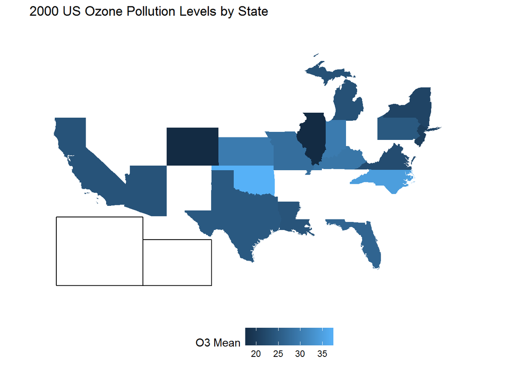

```r
data("fifty_states") # this line is optional due to lazy data loading
dataO3_2000 <- pollution_avg %>%
  filter(Year == 2000)

dataO3_2000$State <- tolower(state.name[match(dataO3_2000$State,state.abb)])

# map_id creates the aesthetic mapping to the state name column in your data
p <- ggplot(dataO3_2000, aes(map_id = dataO3_2000$State)) +
  # map points to the fifty_states shape data
  geom_map(aes(fill = dataO3_2000$'O3 Mean'), map = fifty_states) +
  expand_limits(x = fifty_states$long, y = fifty_states$lat) +
  coord_map() +
  scale_x_continuous(breaks = NULL) +
  scale_y_continuous(breaks = NULL) +
  labs(x = "", y = "", fill="O3 Mean") +
  theme(legend.position = "bottom",
        panel.background = element_blank()) + ggtitle("2000 US Ozone Pollution Levels by State")
p + fifty_states_inset_boxes()
```

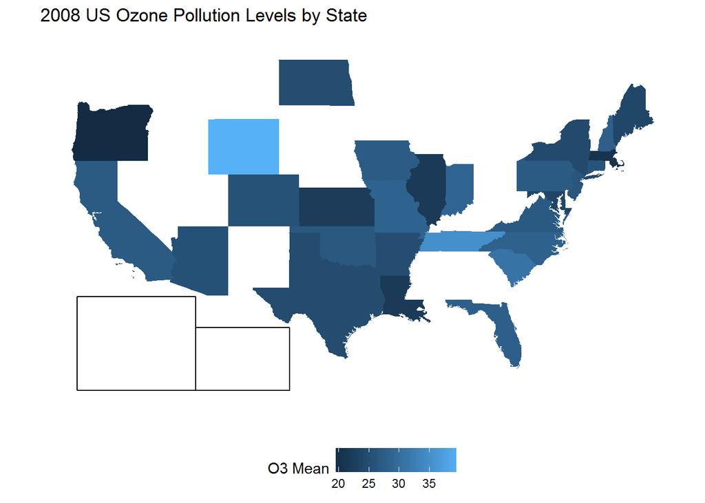

```r
#2008 Data
dataO3_2008 <- pollution_avg %>%
  filter(Year == 2008)

dataO3_2008$State <- tolower(state.name[match(dataO3_2008$State,state.abb)])

# map_id creates the aesthetic mapping to the state name column in your data
p <- ggplot(dataO3_2008, aes(map_id = dataO3_2008$State)) +
  # map points to the fifty_states shape data
  geom_map(aes(fill = dataO3_2008$'O3 Mean'), map = fifty_states) +
  expand_limits(x = fifty_states$long, y = fifty_states$lat) +
  coord_map() +
  scale_x_continuous(breaks = NULL) +
  scale_y_continuous(breaks = NULL) +
  labs(x = "", y = "", fill="O3 Mean") +
  theme(legend.position = "bottom",
        panel.background = element_blank()) + ggtitle("2008 US Ozone Pollution Levels by State")
p + fifty_states_inset_boxes()
```

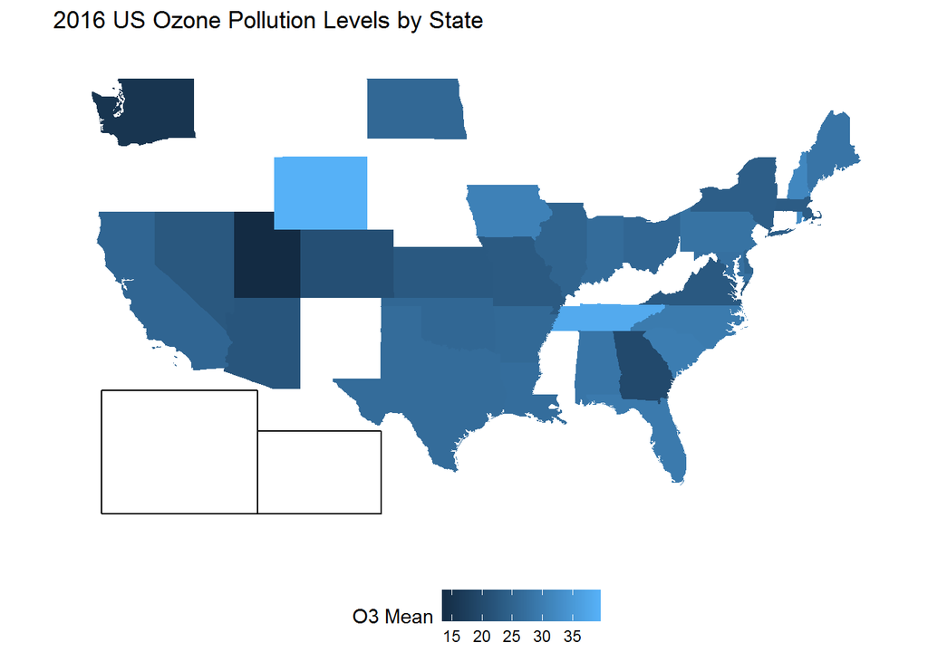

```r
#2016 Data
dataO3_2016 <- pollution_avg %>%
  filter(Year == 2016)

dataO3_2016$State <- tolower(state.name[match(dataO3_2016$State,state.abb)])

# map_id creates the aesthetic mapping to the state name column in your data
p <- ggplot(dataO3_2016, aes(map_id = dataO3_2016$State)) +
  # map points to the fifty_states shape data
  geom_map(aes(fill = dataO3_2016$'O3 Mean'), map = fifty_states) +
  expand_limits(x = fifty_states$long, y = fifty_states$lat) +
  coord_map() +
  scale_x_continuous(breaks = NULL) +
  scale_y_continuous(breaks = NULL) +
  labs(x = "", y = "", fill="O3 Mean") +
  theme(legend.position = "bottom",
        panel.background = element_blank()) + ggtitle("2016 US Ozone Pollution Levels by State")
p + fifty_states_inset_boxes()
```

Nitrogen Dioxide Pollution Levels by state for the years 2000, 2008, and 2016

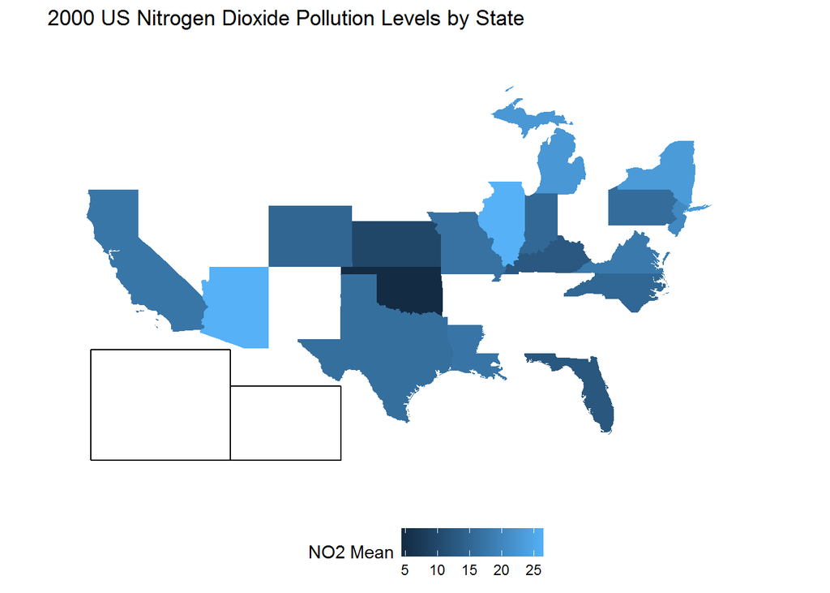

```r
data("fifty_states") # this line is optional due to lazy data loading
dataNO2_2000 <- pollution_avg %>%
  filter(Year == 2000)

dataNO2_2000$State <- tolower(state.name[match(dataNO2_2000$State,state.abb)])

# map_id creates the aesthetic mapping to the state name column in your data
p <- ggplot(dataNO2_2000, aes(map_id = dataNO2_2000$State)) +
  # map points to the fifty_states shape data
  geom_map(aes(fill = dataNO2_2000$'NO2 Mean'), map = fifty_states) +
  expand_limits(x = fifty_states$long, y = fifty_states$lat) +
  coord_map() +
  scale_x_continuous(breaks = NULL) +
  scale_y_continuous(breaks = NULL) +
  labs(x = "", y = "", fill="NO2 Mean") +
  theme(legend.position = "bottom",
        panel.background = element_blank()) + ggtitle("2000 US Nitrogen Dioxide Pollution Levels by State")
p + fifty_states_inset_boxes()
```

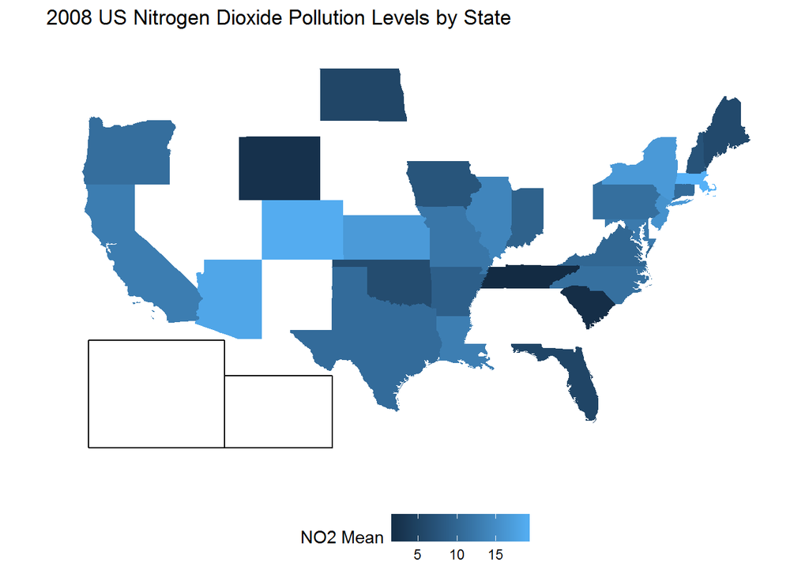

```r
#2008 Data
dataNO2_2008 <- pollution_avg %>%
  filter(Year == 2008)

dataNO2_2008$State <- tolower(state.name[match(dataNO2_2008$State,state.abb)])

# map_id creates the aesthetic mapping to the state name column in your data
p <- ggplot(dataNO2_2008, aes(map_id = dataNO2_2008$State)) +
  # map points to the fifty_states shape data
  geom_map(aes(fill = dataNO2_2008$'NO2 Mean'), map = fifty_states) +
  expand_limits(x = fifty_states$long, y = fifty_states$lat) +
  coord_map() +
  scale_x_continuous(breaks = NULL) +
  scale_y_continuous(breaks = NULL) +
  labs(x = "", y = "", fill="NO2 Mean") +
  theme(legend.position = "bottom",
        panel.background = element_blank()) + ggtitle("2008 US Nitrogen Dioxide Pollution Levels by State")
p + fifty_states_inset_boxes()
```

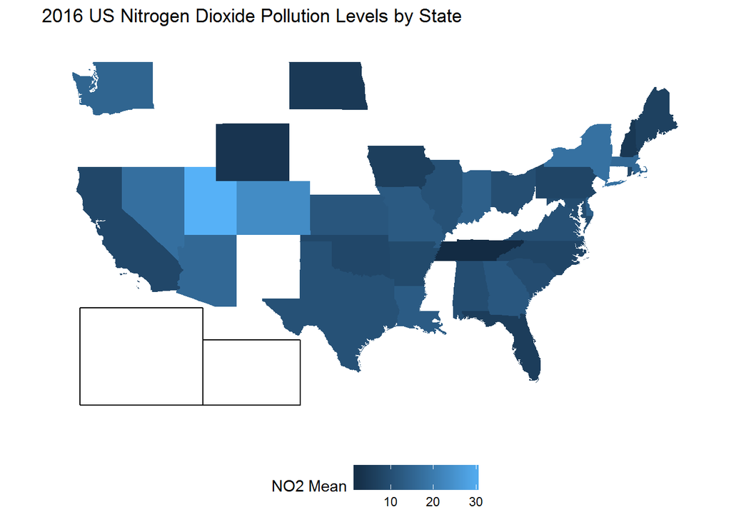

```r
#2016 Data
dataNO2_2016 <- pollution_avg %>%
  filter(Year == 2016)

dataNO2_2016$State <- tolower(state.name[match(dataNO2_2016$State,state.abb)])

# map_id creates the aesthetic mapping to the state name column in your data
p <- ggplot(dataNO2_2016, aes(map_id = dataNO2_2016$State)) +
  # map points to the fifty_states shape data
  geom_map(aes(fill = dataNO2_2016$'NO2 Mean'), map = fifty_states) +
  expand_limits(x = fifty_states$long, y = fifty_states$lat) +
  coord_map() +
  scale_x_continuous(breaks = NULL) +
  scale_y_continuous(breaks = NULL) +
  labs(x = "", y = "", fill="NO2 Mean") +
  theme(legend.position = "bottom",
        panel.background = element_blank()) + ggtitle("2016 US Nitrogen Dioxide Pollution Levels by State")
p + fifty_states_inset_boxes()
```

Nitrogen Dioxide by State  
In 2000, Arizona had the highest Nitrogen Dioxide Concentration. In 2008, Massachusetts thd highest level and in 2016 Utah had the highest level. We can determine this by seeing how lightly colored each state is.